# BIGpopA Tutorial

Pedigree cleaning, validation, parentage assignment and breed composition from SNP genotype data

Josue Chinchilla-Vargas and Alexander Sandercock

2026-10-26

# 1 Introduction

BIGpopA is an R package for pedigree quality control, parentage assignment and breed/line composition from SNP genotypes. It works for diploid and polyploid species and is the analytical engine behind the Familia Shiny app. This guide runs the functions in the order a breeding program usually needs them:

1. Read genotypes as allele-B dosages; VCF and PLINK files are converted automatically. -> `vcf_to_dosage()`, `ped_to_dosage()`
2. Is the pedigree record clean? -> `check_ped()`
3. Do the recorded parents agree with the genotypes? -> `validate_pedigree()`
4. Who are the parents of an individual with unknown or wrong parents? -> `find_parentage()`
5. What is the line / breed composition of each sample? -> `allele_freq_poly()`, `solve_composition_poly()`, `assign_composition_line()`

| Function | Use it to | Main output |
| --- | --- | --- |
| `vcf_to_dosage()` | Convert a VCF to allele-B dosages | Dosage table or matrix |
| `ped_to_dosage()` | Convert a PLINK `.ped` (diploid) to allele-B dosages | Dosage table or matrix |
| `check_ped()` | Fix structural pedigree errors before any genotype work | Corrected pedigree, issue tables |
| `validate_pedigree()` | Test recorded trios against genotypes | Status per trio, corrected pedigree, marker summary |
| `find_parentage()` | Assign or fill in parents from a candidate pool | Best parent(s), error %, ties |
| `allele_freq_poly()` | Allele frequencies of reference lines | Frequency table (markers x lines) |
| `solve_composition_poly()` | Composition of samples from reference frequencies | Proportions and R2 per sample |
| `assign_composition_line()` | Percentages and assigned line per sample | Composition table |

Remarks on the data (violations give misleading results):

- **Genotypes are allele-B dosages** (0 to the ploidy number), not allele pairs: the number of copies of the counted allele, so 0, 1 or 2 in a diploid and 0 to 4 in a tetraploid. VCF and PLINK files are converted automatically; `vcf_to_dosage()` and `ped_to_dosage()` show the converted table (see Converting genotype files).
- **Ploidy is correct.** The Mendelian rules depend on the gametes each parent can produce (ploidy / 2 alleles). A wrong ploidy produces many false failures, so set it to the ploidy of your dosages. Even ploidies use a polysomic gamete-range test (assumes autopolyploid inheritance, so it is conservative for allopolyploids). Odd ploidies (e.g. triploid) fall back to an opposite-homozygote test on homozygous markers only, which has less power.
- **Offspring come from normal sexual reproduction.** Selfed, inbred, doubled-haploid or clonal material can break the assumptions of the trio test (see Tips).
- **Individual ids and marker names match exactly** between files (case and spaces matter). Column names are more flexible; see Input data.

BIGpopA does not call dosages; use your pipeline first (we recommend BIGapp).

# 2 Install

BIGpopA requires R >= 4.4.0. Install it from CRAN by copying and pasting this code into your R console:

```r
install.packages("BIGpopA")
library(BIGpopA)
```

# 3 Input data

BIGpopA works with up to five inputs. Each can be a file path or an in-memory object (data.frame / data.table); genotypes can also be a VCF or a PLINK `.ped` file. This guide builds a small toy dataset that covers the main result categories.

| Input | What it holds | Format | Used by |
| --- | --- | --- | --- |
| Pedigree | The recorded parents of each individual, one row per individual | Columns `id`, `male_parent` and `female_parent`. These names are required but matched ignoring case, spaces and dots (`ID` or `Male parent` also work). Unknown parent = `0`. | `check_ped()`, `validate_pedigree()` |
| Genotypes | The marker calls of every genotyped individual, parents and offspring in the same table | `id` + one column per marker with the allele-B dosage (0 to ploidy), missing call = `NA`; or a VCF / PLINK `.ped` file | `validate_pedigree()`, `find_parentage()` |
| Parents | The candidates `find_parentage()` searches | `id` and an optional `sex` (`M`, `F`, or `A` = either). Without `sex` all candidates are `A`. | `find_parentage()` |
| Progeny | The individuals whose parents you want to find | `id`. For `method = "fill_pedigree"`, a pedigree instead (unknown parent = `0`, `NA` or empty). | `find_parentage()` |
| Founders (optional) | The base-generation individuals, whose parents are unknown by design | A vector of ids, a one-column file or a data.frame (ids in the first column) | `validate_pedigree()`, `find_parentage(method = "fill_pedigree")` |

The same genotype table is used by `validate_pedigree()` and `find_parentage()`. Parents and founders do different jobs. `parents` is the pool of candidates searched by `find_parentage()` and can include any genotyped individual. `founders` only marks the individuals expected to have unknown parents: `validate_pedigree()` reports them as `founders` instead of `missing_both_parents`, and `fill_pedigree` does not search parents for them. In the toy data the four founders are also the four candidate parents.

```r
library(BIGpopA)

# Genotypes: allele-B dosage 0/1/2 (diploid), NA = missing call.
# Parents and offspring are in the same table; C_low is mostly missing.
genotypes = data.frame(
  id    = c("M1","F1","M2","F2","C1","C2","C3","C_bad","C_low"),
  snp01 = c(  0,   0,   2,   2,   0,   2,   1,     0,     NA),
  snp02 = c(  0,   0,   2,   0,   0,   1,   0,     0,     NA),
  snp03 = c(  0,   2,   0,   2,   1,   1,   1,     1,     NA),
  snp04 = c(  0,   2,   0,   0,   1,   0,   0,     1,     NA),
  snp05 = c(  2,   0,   1,   1,   1,   1,   1,     1,     NA),
  snp06 = c(  2,   0,   1,   0,   1,   1,   1,     1,     NA),
  snp07 = c(  2,   2,   0,   1,   2,   0,   2,     2,     NA),
  snp08 = c(  2,   2,   2,   2,   2,   2,   2,     2,     NA),
  snp09 = c(  0,   1,   0,   2,   1,   1,   1,     1,      0),
  snp10 = c(  0,   1,   2,   0,   0,   1,   0,     0,      0),
  snp11 = c(  2,   1,   1,   2,   1,   2,   2,     1,      2),
  snp12 = c(  2,   1,   0,   1,   2,   1,   1,     2,      2),
  stringsAsFactors = FALSE
)

# Pedigree: one row per individual, unknown parents coded 0. It has four
# founders (M1, F1, M2, F2), a mis-assigned trio (C_bad), a sample with mostly
# missing genotypes (C_low) and a duplicated row (C_missing)
pedigree = data.frame(
  id            = c("M1","F1","M2","F2","C1","C2","C3","C_bad","C_low","C_missing","C_missing"),
  male_parent   = c("0", "0", "0", "0", "M1","M2","M1","M2",   "M1",   "M1",       "M1"),
  female_parent = c("0", "0", "0", "0", "F1","F2","F2","F1",   "F1",   "F1",       "F1"),
  stringsAsFactors = FALSE
)

# Founders (optional): individuals whose parents are unknown by design
founders = c("M1", "F1", "M2", "F2")

# For find_parentage(): candidate parents (with sex) and progeny to assign
parents = data.frame(
  id  = c("M1","M2","F1","F2"),
  sex = c("M", "M", "F", "F"),
  stringsAsFactors = FALSE
)

progeny = data.frame(id = c("C1","C2","C3","C_bad","C_low","C_missing"),
                     stringsAsFactors = FALSE)

pedigree
```

| id | male_parent | female_parent |
| --- | --- | --- |
| M1 | 0 | 0 |
| F1 | 0 | 0 |
| M2 | 0 | 0 |
| F2 | 0 | 0 |
| C1 | M1 | F1 |
| C2 | M2 | F2 |
| C3 | M1 | F2 |
| C_bad | M2 | F1 |
| C_low | M1 | F1 |
| C_missing | M1 | F1 |

[output cut: 1 more lines]

```r
genotypes
```

| id | snp01 | snp02 | snp03 | snp04 | snp05 | snp06 | snp07 | snp08 | snp09 | snp10 | snp11 | snp12 |
| --- | --- | --- | --- | --- | --- | --- | --- | --- | --- | --- | --- | --- |
| M1 | 0 | 0 | 0 | 0 | 2 | 2 | 2 | 2 | 0 | 0 | 2 | 2 |
| F1 | 0 | 0 | 2 | 2 | 0 | 0 | 2 | 2 | 1 | 1 | 1 | 1 |
| M2 | 2 | 2 | 0 | 0 | 1 | 1 | 0 | 2 | 0 | 2 | 1 | 0 |
| F2 | 2 | 0 | 2 | 0 | 1 | 0 | 1 | 2 | 2 | 0 | 2 | 1 |
| C1 | 0 | 0 | 1 | 1 | 1 | 1 | 2 | 2 | 1 | 0 | 1 | 2 |
| C2 | 2 | 1 | 1 | 0 | 1 | 1 | 0 | 2 | 1 | 1 | 2 | 1 |
| C3 | 1 | 0 | 1 | 0 | 1 | 1 | 2 | 2 | 1 | 0 | 2 | 1 |
| C_bad | 0 | 0 | 1 | 1 | 1 | 1 | 2 | 2 | 1 | 0 | 1 | 2 |
| C_low | NA | NA | NA | NA | NA | NA | NA | NA | 0 | 0 | 2 | 2 |

`C_bad` is recorded as `M2` x `F1` but is really a child of `M1` x `F1`, and `C_missing` is not genotyped. The next sections show how each function handles these cases.

## 3.1 Converting genotype files

VCF and PLINK files do not need to be converted first: `validate_pedigree()`, `find_parentage()`, `allele_freq_poly()` and `solve_composition_poly()` accept the file path and convert it with their `ploidy`. `vcf_to_dosage()` (VCF, any ploidy) and `ped_to_dosage()` (PLINK `.ped`, diploid) run the same conversion when you want to see or reuse the table. Below are three markers of the toy data for `M1`, `F1` and `C1` in each format.

**example.vcf** (tab-separated; the `GT` calls `0/0`, `0/1` and `1/1` are 0, 1 and 2 copies of the `ALT` allele)

```
##fileformat=VCFv4.3
##FORMAT=<ID=GT,Number=1,Type=String,Description="Genotype">
#CHROM  POS ID  REF ALT QUAL    FILTER  INFO    FORMAT  M1  F1  C1
chr1    100 snp03   A   G   .   .   .   GT  0/0 1/1 0/1
chr1    200 snp05   C   T   .   .   .   GT  1/1 0/0 0/1
chr1    300 snp09   G   A   .   .   .   GT  0/0 0/1 0/1
```

**example.ped** (six pedigree columns, of which only the individual id in column 2 is used, then two alleles per marker)

```
FAM M1 0 0 1 -9 A A T T A A
FAM F1 0 0 2 -9 G G C C A G
FAM C1 M1 F1 0 -9 A G C T A G
```

**example.map** (one row per marker: chromosome, marker name, genetic position, physical position)

```
1 snp03 0 100
1 snp05 0 200
1 snp09 0 300
```

Converting either file gives the same table:

```r
geno_vcf = vcf_to_dosage("example.vcf", verbose = FALSE)   # ploidy read from the GT calls
geno_vcf
```

| id | snp03 | snp05 | snp09 |
| --- | --- | --- | --- |
| M1 | 0 | 2 | 0 |
| F1 | 2 | 0 | 1 |
| C1 | 1 | 1 | 1 |

```r
geno_ped = ped_to_dosage("example.ped", verbose = FALSE)   # example.map in the same folder gives the marker names
geno_ped
```

| id | snp03 | snp05 | snp09 |
| --- | --- | --- | --- |
| M1 | 0 | 2 | 0 |
| F1 | 2 | 0 | 1 |
| C1 | 1 | 1 | 1 |

Both have the layout of `genotypes` and, here, the same values:

```r
genotypes[genotypes$id %in% c("M1", "F1", "C1"), c("id", "snp03", "snp05", "snp09")]
```

|  | id | snp03 | snp05 | snp09 |
| --- | --- | --- | --- | --- |
| 1 | M1 | 0 | 2 | 0 |
| 2 | F1 | 2 | 0 | 1 |
| 5 | C1 | 1 | 1 | 1 |

In a `.ped` file the counted allele is the alphabetically last allele at each marker (`G`, `T` and `G` here). For breed composition, `format = "matrix"` returns the same values with the ids as row names instead of an `id` column:

```r
geno_mat = vcf_to_dosage("example.vcf", format = "matrix", verbose = FALSE)
geno_mat
```

```
##    snp03 snp05 snp09
## M1     0     2     0
## F1     2     0     1
## C1     1     1     1
## attr(,"ploidy")
## [1] 2
```

See `?vcf_to_dosage` and `?ped_to_dosage` for the other options, such as reading a dosage field (`DS`), call-rate filters and multiallelic markers.

## 3.2 Missing data

There are two kinds of missing information, coded differently:

- **Unknown parent** (pedigree): `0`. In a `fill_pedigree` progeny table `NA` or an empty cell also work.
- **Missing genotype call**: `NA` in a dosage table. The converters turn a VCF call containing `.` (for example `./.`) and a `.ped` allele coded `0` into `NA`.

Missing calls never count as errors. Each test only uses the markers where every individual it compares has a call (the tests are explained in How the Mendelian error is calculated):

- **Trio test** (`validate_pedigree()`, and `find_parentage()` with `best_pair` or `fill_pedigree`): markers where the offspring and both parents have a call, the *testable* markers. A trio with fewer testable markers than `min_markers` (default 10) is `low_markers`; one with none is `no_data`.
- **Single-parent test** (recommended corrections, and the single-parent methods of `find_parentage()`): markers where the parent and the offspring are both homozygous. If there are none, the parent counts as failing (see `C_low` in Failed trios and recommended correction).
- **Marker summary**: `mismatch_pct` is `NA` for a marker not tested in any trio.
- **Breed composition**: a sample’s missing calls are skipped marker by marker. A marker missing in every reference individual of a line has no frequency (`NaN` in the output of `allele_freq_poly()`), which makes `solve_composition_poly()` stop with an error. Find these markers with `rownames(freq)[rowSums(is.na(freq)) > 0]` and remove them before rerunning.

# 4 Pedigree cleaning

`check_ped()` works on the columns `id`, `male_parent` and `female_parent`. It applies the checks in this order:

| Issue | Meaning | Action |
| --- | --- | --- |
| Exact duplicates | The identical row appears more than once | Always removed |
| Conflicting trios | Same `id`, different parents in different rows | Disagreeing parents set to `0` and rows collapsed, or flagged (`correct_conflicting_trios = FALSE`) |
| Missing parents | A parent is listed but has no row of its own | Always added as a row with unknown parents (`0`) |
| Inconsistent sex roles | Same individual used as sire and as dam | Set to `0` as a parent everywhere, or flagged (`correct_inconsistent_sex_roles = FALSE`) |
| Cycles / dependencies | An individual is its own ancestor, or is recorded as its own parent | Flagged only; must be fixed manually, since there is no safe automatic choice. Each cycle is listed once, as a path in which every id is a recorded parent of the one before it (`A -> B -> A`) |

Unknown parents must be coded `0`. With `verbose = TRUE` the function prints a report of every check:

```r
clean_ped_results = check_ped(pedigree, verbose = TRUE)
```

```
##
## === Pedigree Quality Check Report ===
##
## Exact duplicate trios detected (removed in corrected pedigree):
##    row_number        id male_parent female_parent
## 10         10 C_missing          M1            F1
## 11         11 C_missing          M1            F1
##
## No conflicting trios found.
##
## No missing parents found.
##
## No IDs found as both male_parent and female_parent.
##
## No dependencies detected.
##
## The corrected pedigree is included in the returned list as corrected_pedigree.
```

The result is a list with one table per issue plus the corrected pedigree. An empty table means the issue was not found:

```r
names(clean_ped_results)
```

```
## [1] "exact_duplicates"       "conflicting_trios"      "inconsistent_sex_roles"
## [4] "missing_parents"        "dependencies"           "corrected_pedigree"
```

```r
sapply(clean_ped_results, nrow)   # number of rows in each table
```

```
##       exact_duplicates      conflicting_trios inconsistent_sex_roles
##                      2                      0                      0
##        missing_parents           dependencies     corrected_pedigree
##                      0                      0                     10
```

| Element | In the toy data |
| --- | --- |
| `exact_duplicates` | Both copies of the repeated `C_missing` row; `row_number` is their position in the input |
| `conflicting_trios` | Empty: no id has two different sets of parents |
| `inconsistent_sex_roles` | Empty: no individual is used as both male and female parent |
| `missing_parents` | Empty: every parent has its own row |
| `dependencies` | Empty: no cycles |
| `corrected_pedigree` | The pedigree without the duplicate, ready for `validate_pedigree()` |

```r
clean_ped_results$exact_duplicates
```

|  | row_number | id | male_parent | female_parent |
| --- | --- | --- | --- | --- |
| 10 | 10 | C_missing | M1 | F1 |
| 11 | 11 | C_missing | M1 | F1 |

```r
# the corrected, analysis-ready pedigree
clean_ped = clean_ped_results$corrected_pedigree
clean_ped
```

| id | male_parent | female_parent |
| --- | --- | --- |
| M1 | 0 | 0 |
| F1 | 0 | 0 |
| M2 | 0 | 0 |
| F2 | 0 | 0 |
| C1 | M1 | F1 |
| C2 | M2 | F2 |
| C3 | M1 | F2 |
| C_bad | M2 | F1 |
| C_low | M1 | F1 |
| C_missing | M1 | F1 |

# 5 Pedigree validation

`validate_pedigree()` tests every trio (offspring, male parent, female parent) of the pedigree against the genotypes. It returns the status of each trio, a recommended correction when a trio fails, a corrected pedigree and a per-marker summary. Here the founders are passed with `founders_file`, and `marker_trio_table = TRUE` adds the marker-by-trio table used below. Click the label under the code to see the console report.

```r
ped_validate_results = validate_pedigree(clean_ped, genotypes,
                                         founders_file     = founders,
                                         marker_trio_table = TRUE,
                                         verbose = TRUE, plot_results = TRUE)
```

**Show the report printed with verbose = TRUE**

```
## Found 1 trios with missing genotype data; flagged as no_genotype_data.
##
## --- Trio Validation Summary ---
## Total trios in pedigree: 10
## fail                        : 1 (10.0%)
## founders                    : 4 (40.0%)
## low_markers                 : 1 (10.0%)
## no_genotype_data            : 1 (10.0%)
## pass                        : 3 (30.0%)
## Error threshold: 5%
## Homozygous threshold: 2%
## Minimum markers required: 10
##
## Correction summary:
##   low_markers_remove_female_parent: 1
##   remove_male_parent: 1
##
##            id orig_male_parent orig_female_parent trio_mendelian_error_pct
##        <char>           <char>             <char>                    <num>
##  1:        M1                0                  0                       NA
##  2:        F1                0                  0                       NA
##  3:        M2                0                  0                       NA
##  4:        F2                0                  0                       NA
##  5:        C1               M1                 F1                     0.00
##  6:        C2               M2                 F2                     0.00
##  7:        C3               M1                 F2                     0.00
##  8:     C_bad               M2                 F1                    41.67
##  9:     C_low               M1                 F1                     0.00
## 10: C_missing               M1                 F1                       NA
##     trio_markers_tested           status           recommended_correction
##                   <int>           <char>                           <char>
##  1:                   0         founders                             none
##  2:                   0         founders                             none
##  3:                   0         founders                             none
##  4:                   0         founders                             none
##  5:                  12             pass                             none
##  6:                  12             pass                             none
##  7:                  12             pass                             none
##  8:                  12             fail               remove_male_parent
##  9:                   4      low_markers low_markers_remove_female_parent
## 10:                   0 no_genotype_data                             none
##     male_parent_hom_error_pct female_parent_hom_error_pct
##                         <num>                       <num>
##  1:                        NA                          NA
##  2:                        NA                          NA
##  3:                        NA                          NA
##  4:                        NA                          NA
##  5:                        NA                          NA
##  6:                        NA                          NA
##  7:                        NA                          NA
##  8:                     83.33                           0
##  9:                      0.00                          NA
## 10:                        NA                          NA
```

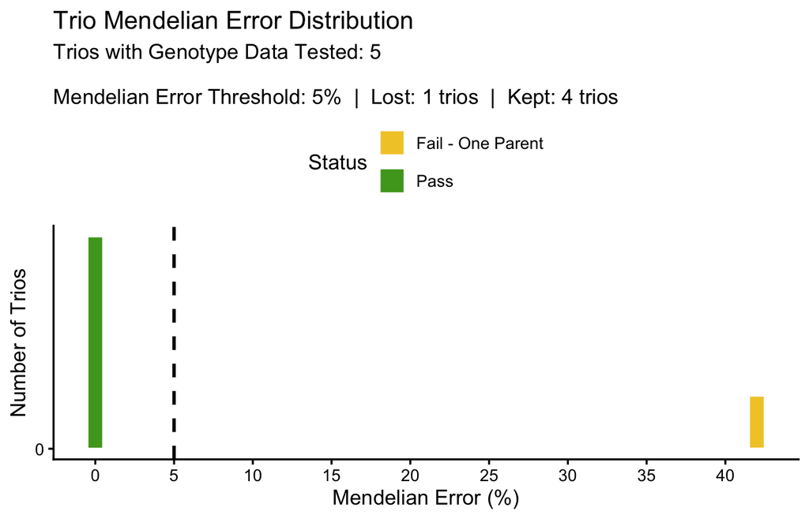

The result is a list. `full_results` has one row per trio, and `pass`, `fail`, `low_markers`, `no_genotype_data`, `founders` and `missing_parents` hold the same rows split by status. `corrected_pedigree`, `marker_summary` and `marker_trio_table` are described below, and `plot` is the histogram above.

```r
names(ped_validate_results)
```

```
##  [1] "pass"               "fail"               "low_markers"
##  [4] "no_genotype_data"   "founders"           "missing_parents"
##  [7] "full_results"       "corrected_pedigree" "marker_summary"
## [10] "marker_trio_table"  "plot"
```

```r
sapply(Filter(is.data.frame, ped_validate_results), nrow)   # rows in each table
```

```
##               pass               fail        low_markers   no_genotype_data
##                  3                  1                  1                  1
##           founders    missing_parents       full_results corrected_pedigree
##                  4                  0                 10                 10
##     marker_summary  marker_trio_table
##                 12                 12
```

```r
ped_validate_report = ped_validate_results$full_results
ped_validate_report
```

| id | orig_male_parent | orig_female_parent | trio_mendelian_error_pct | trio_markers_tested | status | recommended_correction | male_parent_hom_error_pct | female_parent_hom_error_pct |
| --- | --- | --- | --- | --- | --- | --- | --- | --- |
| M1 | 0 | 0 | NA | 0 | founders | none | NA | NA |
| F1 | 0 | 0 | NA | 0 | founders | none | NA | NA |
| M2 | 0 | 0 | NA | 0 | founders | none | NA | NA |
| F2 | 0 | 0 | NA | 0 | founders | none | NA | NA |
| C1 | M1 | F1 | 0.00 | 12 | pass | none | NA | NA |
| C2 | M2 | F2 | 0.00 | 12 | pass | none | NA | NA |
| C3 | M1 | F2 | 0.00 | 12 | pass | none | NA | NA |
| C_bad | M2 | F1 | 41.67 | 12 | fail | remove_male_parent | 83.33 | 0 |
| C_low | M1 | F1 | 0.00 | 4 | low_markers | low_markers_remove_female_parent | 0.00 | NA |
| C_missing | M1 | F1 | NA | 0 | no_genotype_data | none | NA | NA |

In `full_results`, `trio_mendelian_error_pct` is the trio error over `trio_markers_tested` testable markers, and `male_parent_hom_error_pct` and `female_parent_hom_error_pct` are the single-parent errors, computed only for failed and low-marker trios. The thresholds used here are the defaults; they and the other settings are arguments of the function (see `?validate_pedigree`).

## 5.1 How the Mendelian error is calculated

The trio error uses **every marker where the offspring and both parents have a call**, heterozygous or homozygous, not only the homozygous ones. At each testable marker the question is whether the two parents can produce the offspring. Each parent passes on a gamete with half of its alleles (ploidy / 2), so a parent with dosage *g* passes between max(0, *g* − ploidy / 2) and min(*g*, ploidy / 2) copies of allele B. The offspring dosage must lie between the sum of the two parents’ minimums and the sum of their maximums; otherwise the marker is a Mendelian error. For a diploid this gives the familiar rules:

| Male parent | Female parent | Possible offspring |
| --- | --- | --- |
| 0 | 0 | 0 |
| 0 | 1 | 0 or 1 |
| 0 | 2 | 1 |
| 1 | 1 | 0, 1 or 2 |
| 1 | 2 | 1 or 2 |
| 2 | 2 | 2 |

For a tetraploid, a parent with dosage 3 passes 1 or 2 copies, so a 3 x 0 cross can only give 1 or 2. The trio error is then

> trio error (%) = 100 × markers with an error / testable markers

and the trio passes when it is at or below `trio_error_threshold` (default 5%). For odd ploidy (e.g. triploid) gametes are unbalanced, so the trio test falls back to the opposite-homozygote check of the single-parent test (see Failed trios and recommended correction): a marker is an error when the offspring is homozygous and a homozygous parent carries the other allele.

Here is the trio of `C_bad` (recorded as `M2` x `F1`) marker by marker, with the verdict from `marker_trio_table`:

```r
c_bad_trio = data.frame(
  marker  = ped_validate_results$marker_trio_table$marker,
  M2      = unlist(genotypes[genotypes$id == "M2",    -1]),
  F1      = unlist(genotypes[genotypes$id == "F1",    -1]),
  C_bad   = unlist(genotypes[genotypes$id == "C_bad", -1]),
  verdict = ped_validate_results$marker_trio_table$C_bad_M2_F1,
  row.names = NULL
)
c_bad_trio
```

| marker | M2 | F1 | C_bad | verdict |
| --- | --- | --- | --- | --- |
| snp01 | 2 | 0 | 0 | mismatch_male |
| snp02 | 2 | 0 | 0 | mismatch_male |
| snp03 | 0 | 2 | 1 | match |
| snp04 | 0 | 2 | 1 | match |
| snp05 | 1 | 0 | 1 | match |
| snp06 | 1 | 0 | 1 | match |
| snp07 | 0 | 2 | 2 | mismatch_male |
| snp08 | 2 | 2 | 2 | match |
| snp09 | 0 | 1 | 1 | match |
| snp10 | 2 | 1 | 0 | mismatch_male |

[output cut: 2 more lines]

5 of the 12 testable markers are errors, a trio error of 41.67%, so the trio fails. At `snp01`, for example, `M2` is 2 and `F1` is 0, so every child must be 1, but `C_bad` is 0. Heterozygous markers count too: at `snp10` the cross 2 x 1 can only give 1 or 2, and `C_bad` is 0. All errors are labelled `mismatch_male`, meaning `M2` cannot be the parent whatever `F1` contributes; the single-parent test below confirms this.

## 5.2 Status of each trio

| Status | Meaning |
| --- | --- |
| `pass` | Trio error at or below `trio_error_threshold` |
| `fail` | Trio error above the threshold |
| `low_markers` | Fewer than `min_markers` testable markers |
| `no_genotype_data` | At least one of the three individuals is not in the genotype table |
| `founders` | Both parents `0` and the id is listed in `founders_file` |
| `missing_both_parents`, `missing_male_parent`, `missing_female_parent` | One or both parents are `0`, and the individual is not a listed founder |
| `no_data` | No testable marker at all (only in `full_results`) |

In the toy data `C1`, `C2` and `C3` pass, `C_bad` fails, `C_low` is `low_markers` and `C_missing` has `no_genotype_data`. `M1`, `F1`, `M2` and `F2` are `founders` because they are listed in `founders`; without `founders_file` they would be `missing_both_parents`.

## 5.3 Failed trios and recommended correction

A failed trio shows that the pair is wrong, but not which parent. Each parent is therefore tested alone with the **single-parent test**, which uses only the markers where the parent and the offspring are both homozygous. A parent homozygous for one allele passes that allele to every child, so a child homozygous for the other allele (0 vs 2 in a diploid) cannot be its offspring. Heterozygous markers are left out because, without the other parent, they rarely rule a parent out.

> single-parent error (%) = 100 × markers where parent and offspring are homozygous for different alleles / markers where both are homozygous

A parent fails when this error is above `single_parent_error_threshold` (default 2%), or when there is no marker to compare. For `C_bad`, `M2` has a single-parent error of 83.33% and `F1` of 0%, so the recommendation is `remove_male_parent`. The `recommended_correction` column gives the result for every trio:

| `recommended_correction` | Interpretation |
| --- | --- |
| `none` | Trio passes, or it is a founder, has a missing parent, has no genotype data or has no testable marker |
| `remove_male_parent` | The trio fails and only the male parent fails the single-parent test |
| `remove_female_parent` | The trio fails and only the female parent fails the single-parent test |
| `remove_both` | The trio fails and both parents fail the single-parent test |
| `unresolved` | The trio fails but neither parent fails the single-parent test, for example an offspring recorded as its own parent; the pedigree is probably wrong but the faulty parent cannot be identified |
| `low_markers_*` | The trio has fewer than `min_markers` testable markers; the suffix is the decision the same rules would give (`low_markers_keep_both` means the error is within the threshold and both parents pass) |

`C_low` shows the weak point of having few markers. Its trio error is 0%, but `F1` is heterozygous at all 4 of its testable markers, so the single-parent test has nothing to compare for `F1`. `F1` then counts as failing, and the recommendation is `low_markers_remove_female_parent`. Treat `low_markers_*` recommendations with caution, and genotype these samples again if possible.

```r
ped_validate_results$corrected_pedigree
```

| id | male_parent | female_parent |
| --- | --- | --- |
| M1 | 0 | 0 |
| F1 | 0 | 0 |
| M2 | 0 | 0 |
| F2 | 0 | 0 |
| C1 | M1 | F1 |
| C2 | M2 | F2 |
| C3 | M1 | F2 |
| C_bad | 0 | F1 |
| C_low | M1 | 0 |
| C_missing | M1 | F1 |

`corrected_pedigree` sets the parent(s) named by the recommendation to `0`, here the male parent of `C_bad` and the female parent of `C_low`. `unresolved` trios are left unchanged for manual review. Run `find_parentage()` with `method = "fill_pedigree"` on the corrected pedigree to look for the right parents (see Filling in missing parents of a pedigree).

## 5.4 Marker summary

`marker_summary` lists every marker with `trios_tested`, `trios_mismatch` and `mismatch_pct`, sorted worst first. It answers a different question than the trio table: *is the problem the individual or the marker?* A few markers with a mismatch % far above the rest (paralogous loci, poor clustering, null alleles) inflate the error of many trios. Remove them from the genotype file and rerun.

```r
head(ped_validate_results$marker_summary)
```

| marker | trios_tested | trios_mismatch | mismatch_pct |
| --- | --- | --- | --- |
| snp01 | 4 | 1 | 25 |
| snp02 | 4 | 1 | 25 |
| snp07 | 4 | 1 | 25 |
| snp10 | 5 | 1 | 20 |
| snp12 | 5 | 1 | 20 |
| snp03 | 4 | 0 | 0 |

## 5.5 Marker x trio table

With `marker_trio_table = TRUE` (as in the run above), the result includes the verdict of every marker for every trio with both parents known and genotyped. Columns are named `id_male_female`; the `C_bad_M2_F1` column was used above.

```r
ped_validate_results$marker_trio_table
```

| marker | C1_M1_F1 | C2_M2_F2 | C3_M1_F2 | C_bad_M2_F1 | C_low_M1_F1 |
| --- | --- | --- | --- | --- | --- |
| snp01 | match | match | match | mismatch_male | missing_progeny |
| snp02 | match | match | match | mismatch_male | missing_progeny |
| snp03 | match | match | match | match | missing_progeny |
| snp04 | match | match | match | match | missing_progeny |
| snp05 | match | match | match | match | missing_progeny |
| snp06 | match | match | match | match | missing_progeny |
| snp07 | match | match | match | mismatch_male | missing_progeny |
| snp08 | match | match | match | match | missing_progeny |
| snp09 | match | match | match | match | match |
| snp10 | match | match | match | mismatch_male | match |

[output cut: 2 more lines]

| Label | Meaning |
| --- | --- |
| `match` | The trio is consistent at this marker |
| `mismatch_male`, `mismatch_female` | Only that parent is inconsistent with the offspring |
| `mismatch_both` | Each parent alone is inconsistent with the offspring |
| `mismatch_combination` | Each parent alone is compatible, but the pair cannot produce the offspring |
| `missing_male`, `missing_female`, `missing_progeny` | That individual has no call; every missing individual is named (for example `missing_progeny_male_female`) |
| `untestable` | No call is missing, but the marker cannot be tested (odd ploidy, offspring not homozygous) |

# 6 Parentage assignment

When parentage is unknown, `find_parentage()` tests every candidate in `parents` against each individual in `progeny` and reports the best one. How candidates are scored depends on the method; the score is reported as `mendelian_error_pct`, and lower is better:

| Method | Candidates tested | Score |
| --- | --- | --- |
| `best_pair` (default) | Every male x female pair | Trio error, as in `validate_pedigree()`: all markers where the three individuals have a call |
| `best_male_parent`, `best_female_parent` | Each candidate of that sex alone | Single-parent error: only markers homozygous in both candidate and progeny |
| `best_match` | Each candidate of either sex alone | Single-parent error, as above |
| `fill_pedigree` | The missing parent(s) of a pedigree; a known parent is kept fixed | Trio error (see Filling in missing parents of a pedigree) |

Only the single-parent methods rely on homozygous markers. Prefer `best_pair` when both parents are among the candidates: it uses all markers and both parents together, so it separates candidates much better. Use the single-parent methods when the other parent is not genotyped.

The best candidate is always reported, with a status: `pass` (score at or below `error_threshold`, default 5%), `high_error` (above it: no candidate fits well, so the true parent may be missing from `parents`), `low_markers` (fewer than `min_markers` markers tested) or, for `fill_pedigree`, `known_parent_no_genotype`. See `?find_parentage` for all options.

```r
find_parentage_results = find_parentage(genotypes, parents, progeny,
                                        method = "best_pair",
                                        verbose = TRUE, plot_results = TRUE)
```

**Show the report printed with verbose = TRUE**

```
## Parent selfing is disallowed. Pairs with identical parents are removed.
##
## === Parentage Assignment Report ===
##
## Total progeny evaluated: 5
## Method: best_pair  |  Error threshold: 5%  |  Minimum markers: 10
##
## 4 progeny passed (80.0%).
##
## No progeny flagged for high error.
##
## 1 progeny flagged low_markers (20.0%):
##        id male_parent female_parent mendelian_error_pct markers_tested
##    <char>      <char>        <char>              <char>          <int>
## 1:  C_low          M1            F1                0.00              4
##         status tied_candidates
##         <char>           <int>
## 1: low_markers               1
##
## Full results are included in the returned list as $full_results.
```

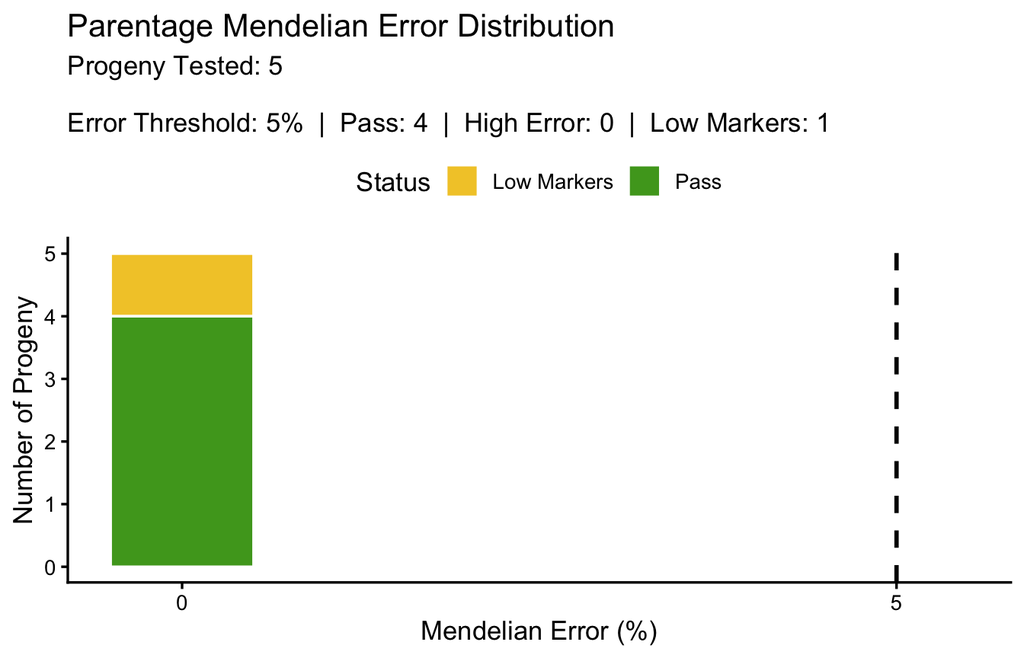

The result is a list like the one from `validate_pedigree()`: `full_results` has one row per progeny, `pass`, `high_error` and `low_markers` hold the same rows split by status, and `plot` is the histogram above.

```r
names(find_parentage_results)
```

```
## [1] "pass"         "high_error"   "low_markers"  "full_results" "plot"
```

```r
sapply(Filter(is.data.frame, find_parentage_results), nrow)   # rows in each table
```

```
##         pass   high_error  low_markers full_results
##            4            0            1            5
```

```r
find_parentage_report = find_parentage_results$full_results
find_parentage_report
```

| id | male_parent | female_parent | mendelian_error_pct | markers_tested | status | tied_candidates |
| --- | --- | --- | --- | --- | --- | --- |
| C1 | M1 | F1 | 0.00 | 12 | pass | 1 |
| C2 | M2 | F2 | 0.00 | 12 | pass | 1 |
| C3 | M1 | F2 | 0.00 | 12 | pass | 1 |
| C_bad | M1 | F1 | 0.00 | 12 | pass | 1 |
| C_low | M1 | F1 | 0.00 | 4 | low_markers | 1 |

Each row gives the best pair (`male_parent`, `female_parent`), its error (`mendelian_error_pct`), the number of markers tested, the status and `tied_candidates`, the number of pairs that share the best error. `C1`, `C2` and `C3` get their recorded parents at 0% error, and `C_bad`, which failed validation, is recovered to its true pair (`M1` x `F1`). `C_low` also gets `M1` x `F1`, but on only 4 markers, so it stays `low_markers`. `C_missing` is not in the genotype table, so it is dropped with a warning.

## 6.1 Top N and ties

`tied_candidates` above 1 means several candidates share the best error, so the assignment is ambiguous; this is common with few markers or with clones. To see how close the alternatives are, set `top_n`:

```r
top3_results = find_parentage(genotypes, parents, progeny, method = "best_pair",
                              top_n = 3, verbose = FALSE, plot_results = FALSE)
names(top3_results)
```

```
## [1] "pass"         "high_error"   "low_markers"  "full_results" "plot"
```

```r
top3 = top3_results$full_results
top3
```

| id | male_parent | female_parent | mendelian_error_pct | markers_tested | status | tied_candidates | male_parent_2 | female_parent_2 | mendelian_error_pct_2 | markers_tested_2 | male_parent_3 | female_parent_3 | mendelian_error_pct_3 | markers_tested_3 |
| --- | --- | --- | --- | --- | --- | --- | --- | --- | --- | --- | --- | --- | --- | --- |
| C1 | M1 | F1 | 0.00 | 12 | pass | 1 | M1 | F2 | 25.00 | 12 | M2 | F1 | 41.67 | 12 |
| C2 | M2 | F2 | 0.00 | 12 | pass | 1 | M2 | F1 | 25.00 | 12 | M1 | F1 | 33.33 | 12 |
| C3 | M1 | F2 | 0.00 | 12 | pass | 1 | M1 | F1 | 16.67 | 12 | M2 | F1 | 33.33 | 12 |
| C_bad | M1 | F1 | 0.00 | 12 | pass | 1 | M1 | F2 | 25.00 | 12 | M2 | F1 | 41.67 | 12 |
| C_low | M1 | F1 | 0.00 | 4 | low_markers | 1 | M1 | F2 | 25.00 | 4 | M2 | F1 | 50.00 | 4 |

The list has the same elements; only `full_results` gains columns. Rank 1 stays in the base columns (`male_parent`, `female_parent`, `mendelian_error_pct`, `markers_tested`), and ranks 2 and 3 are added with the suffixes `_2` and `_3` (`male_parent_2`, `female_parent_2`, `mendelian_error_pct_2`, `markers_tested_2`, and so on). `status` and `tied_candidates` refer to rank 1. A large gap between ranks means a clear assignment: for `C_bad` the best pair has 0.00% error and the second best (M1 x F2) 25%. With the default `top_n = 1`, tied best pairs are added in the same suffix columns (`show_ties = TRUE`).

## 6.2 Filling in missing parents of a pedigree

With `method = "fill_pedigree"`, `progeny` is a pedigree (`id`, `male_parent`, `female_parent`), typically the `corrected_pedigree` from `validate_pedigree()`. Parents coded `0`, `NA` or empty are unknown. Each row is handled on its own: a known male parent searches only females, a known female parent only males, and a row with both parents unknown gets the full pair search, unless it is a listed founder. Rows with both parents known are skipped. The `parents` table (with sex) is still required.

```r
filled_results = find_parentage(genotypes, parents,
                                ped_validate_results$corrected_pedigree,
                                method        = "fill_pedigree",
                                founders_file = founders,
                                verbose = FALSE, plot_results = FALSE)
names(filled_results)
```

```
## [1] "pass"         "high_error"   "low_markers"  "full_results" "plot"
```

```r
filled_results$full_results
```

| id | male_parent | female_parent | mendelian_error_pct | markers_tested | status | tied_candidates | search_mode | known_parent_error_pct |
| --- | --- | --- | --- | --- | --- | --- | --- | --- |
| C_bad | M1 | F1 | 0.00 | 12 | pass | 1 | known_female | 0 |
| C_low | M1 | F1 | 0.00 | 4 | low_markers | 1 | known_male | 0 |

The list has the same elements as before. Only the rows with a parent removed by validation are searched: the founders are skipped because they are in `founders`, and the complete trios because both parents are known. `full_results` gains two columns: `search_mode` (`known_male`, `known_female`, or `pair` when both parents are unknown) and `known_parent_error_pct`, the single-parent error of the parent that was kept (a high value suggests that it is wrong too). `C_bad` kept `F1`, so only males were tested, and `M1` is found at 0%. `C_low` kept `M1` and gets `F1` back, but on too few markers, so it stays `low_markers`.

# 7 Breed and line composition

BIGpopA estimates genome-wide breed or line composition for diploid and polyploid populations with a breedTools-style quadratic programming approach (Funkhouser et al. 2017). The workflow has three steps: compute reference-line allele frequencies, estimate the composition of each sample, and assign each sample to a line. This example mirrors an autotetraploid analysis (`ploidy = 4`) that assigns samples to two cultivar reference panels, Jewel and Draper.

```r
# reference genotypes: individuals x SNPs, tetraploid dosage of allele B (0..4)
reference = data.frame(
  S1 = c(0, 1, 0, 4, 3, 4),
  S2 = c(1, 0, 0, 3, 4, 4),
  S3 = c(0, 1, 1, 4, 3, 3),
  S4 = c(1, 0, 1, 3, 4, 3),
  S5 = c(0, 1, 0, 4, 3, 4),
  S6 = c(1, 0, 1, 3, 4, 3),
  row.names = c("Jewel1","Jewel2","Jewel3","Draper1","Draper2","Draper3")
)

# reference panel membership (which individuals define each cultivar)
ref_ids = list(
  Jewel  = c("Jewel1","Jewel2","Jewel3"),
  Draper = c("Draper1","Draper2","Draper3")
)

# allele frequencies of the reference panels (SNPs x panels)
freq = allele_freq_poly(reference, ref_ids, ploidy = 4)
freq
```

```
##         Jewel    Draper
## S1 0.08333333 0.9166667
## S2 0.08333333 0.9166667
## S3 0.16666667 0.8333333
## S4 0.16666667 0.8333333
## S5 0.08333333 0.9166667
## S6 0.16666667 0.8333333
```

The references should be representative, unadmixed individuals; the more distinct the references, the better the estimate. Marker names must match between the reference and the samples.

```r
# samples to assign: samples x SNPs (same SNPs as the reference)
validation = data.frame(
  S1 = c(0, 4, 2),
  S2 = c(1, 3, 2),
  S3 = c(0, 4, 2),
  S4 = c(1, 3, 2),
  S5 = c(0, 4, 2),
  S6 = c(1, 3, 2),
  row.names = c("Sample1","Sample2","Sample3")
)

# composition (one column per panel plus an R2 model-fit column)
prediction = as.data.frame(solve_composition_poly(validation, freq, ploidy = 4))
prediction
```

|  | Jewel | Draper | R2 |
| --- | --- | --- | --- |
| Sample1 | 1.000000e+00 | 2.408405e-16 | 0.1111111 |
| Sample2 | 4.834614e-16 | 1.000000e+00 | 0.1111111 |
| Sample3 | 5.000000e-01 | 5.000000e-01 | NA |

`R2` measures how well the estimated mixture of reference lines explains a sample’s genotypes. The sample’s dosages are divided by the ploidy (0, 0.25, …, 1 for a tetraploid); the predicted value at each marker is the allele frequency of the reference lines weighted by the estimated proportions; and `R2` is the squared correlation between the two across the sample’s non-missing markers. It describes the fit, not the accuracy of the proportions. It is usually well below 1 even for a pure individual, because each genotype is one of a few discrete values while the prediction is a frequency, so every marker at which the line is polymorphic adds unexplained variation. Compare `R2` between samples analysed with the same reference panel and markers: a sample with a much lower `R2` than the rest may come from a population that is not in the reference panel, or have poor-quality genotypes.

`assign_composition_line()` turns the result into the table used by Familia: the estimated percentage of each panel and a `Predicted line`. A sample is assigned to its highest-proportion line only if that proportion is at least `assign_threshold` (default 50); otherwise it is labelled `Undetermined`. With `assign_threshold = 0` every sample is assigned.

```r
pred_results = assign_composition_line(solve_composition_poly(validation, freq, ploidy = 4))
pred_results
```

| ID | Jewel | Draper | Predicted line |
| --- | --- | --- | --- |
| Sample1 | 100 | 0 | Jewel |
| Sample2 | 0 | 100 | Draper |
| Sample3 | 50 | 50 | Jewel |

`Sample1` is assigned Jewel and `Sample2` Draper (each essentially 100%), while the admixed `Sample3` splits roughly evenly between them. For diploid data set `ploidy = 2`. Save the table with `write.table(pred_results, "composition.txt", sep = "\t", row.names = FALSE)`.

# 8 Complete workflow

```r
# genotypes: a dosage table, or pass the VCF / .ped path straight to each function
genotypes = vcf_to_dosage("my_markers.vcf.gz", ploidy = 4)

# pedigree quality control
clean_ped = check_ped(pedigree)$corrected_pedigree
validated = validate_pedigree(clean_ped, genotypes, founders_file = founders, ploidy = 4)

# look for the parents removed by validation (and any other missing parent)
filled = find_parentage(genotypes, parents, validated$corrected_pedigree,
                        method = "fill_pedigree", founders_file = founders, ploidy = 4)

# or assign parents to new progeny
assigned = find_parentage(genotypes, parents, progeny, method = "best_pair", ploidy = 4)

# breed/line composition
freq              = allele_freq_poly(reference, ref_ids, ploidy = 4)
prediction        = solve_composition_poly(validation, freq, ploidy = 4)
composition_table = assign_composition_line(prediction, assign_threshold = 50)
```

# 9 Tips

- Typical workflow: `check_ped()` -> `validate_pedigree()` -> `find_parentage()` (`fill_pedigree`) on the corrected pedigree.
- Make sure you are using the right ploidy. A wrong ploidy gives many false failures.
- List your founders in `founders_file`, so their unknown parents are not reported as missing.
- Selfed or inbred offspring can fail the trio test; check the single-parent errors and the `unresolved` flag.
- Ties are common with few markers or with clones; always check `tied_candidates`.
- Check `marker_summary` before blaming individuals; remove bad markers and rerun.

# 10 How to cite

## 10.1 BIGpopA

Chinchilla-Vargas J, Sandercock AM (2026). *BIGpopA: Pedigree Validation Genetic Composition of Diploids & Polyploids*. R package version 2.2.1. CRAN: https://CRAN.R-project.org/package=BIGpopA

Run `citation("BIGpopA")` in R for the BibTeX entry.

## 10.2 Methods

- Funkhouser SA, Bates RO, Ernst CW, Newcom D, Steibel JP (2017). Estimation of genome-wide and locus-specific breed composition in pigs. *Translational Animal Science* 1(1):36-44. https://doi.org/10.2527/tas2016.0003